# Effects of Prosper Scores on Getting Loans- by Geoffrey ANDIMA

## Dataset Overview

This data set contains 113,937 loans with 81 variables on each loan, including loan amount, borrower rate (or interest rate), current loan status, borrower income, and many others.

### Main feature(s) of Interest in the dataset?

- **LoanStatus:** The current status of the loan.
- **Term:** The length of the Loan in terms of months.
- **EmploymentStatus:** Employment status, when listing was created
- **BorrowerState:** The state in which the borrower comes from/resides.
- **BorrowerRate:** Interest Rate on the loan taken by the borrower.
- **ListingCategory (numeric):** The category of the loan.
- **ProsperScore:** Custom Risk Score
- **EstimatedLoss:** Estimated Principal loss.
- **IsBorrowerHomeowner:** Does the borrower own a home ?
- **CreditScoreRange:** The upper and lower values of the Credit Score Range.
- **MonthlyLoanPayment:** The monthly installment that is to be paid.
- **LoanOriginationDate:** The date at which the loan was issued.
- **StatedMonthlyIncome:** The monthly income of the borrower stated at the time the loan was issued.
- **IncomeRange:** IncomeRange of borrowers.

### Features in the dataset that supported the investigation

> **Prosper Score was used to help determine worthness and abilty of borrowers to pay back., Home ownership was used to help understand if Home ownership status had an effect on getting loans.**

# QN: What are the top 10 states with the least number of borrowers?

**INSIGHT:** **It was observed that the state with the least number of borrowers was North DAKOTA with 52 borrowers, followed by Maine with 101, Wyoming with 150,and Iowa with 186**

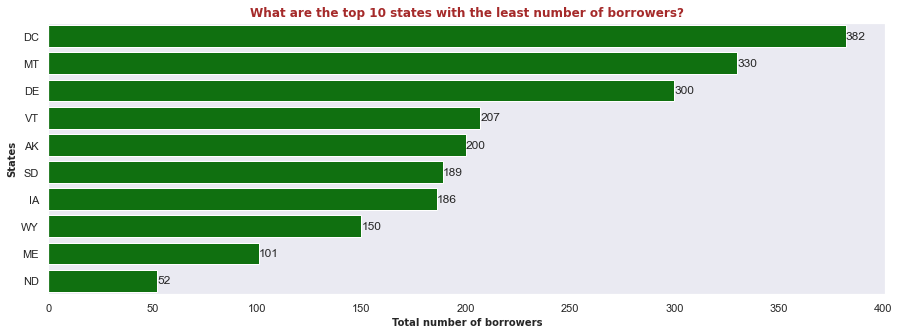

```python
sb.set(style='dark',)
plt.figure(figsize=(15,5))

ax = sb.barplot(x=least_borrower_totals, y=least_borrower_states, color = 'green')
plt.xlabel('Total number of borrowers',size=10,fontname="DejaVu Sans", fontweight="bold")
plt.ylabel('States',size=10,fontname="DejaVu Sans", fontweight="bold")
plt.title('What are the top 10 states with the least number of borrowers?' , size=12, fontname="DejaVu Sans", color ="brown", fontweight="bold")

#lets now display the value lables using containers as shwoed in the class.
for i in ax.containers:
    ax.bar_label(i,)
```

# QN: What are the top 10 states with the most number of borrowers?

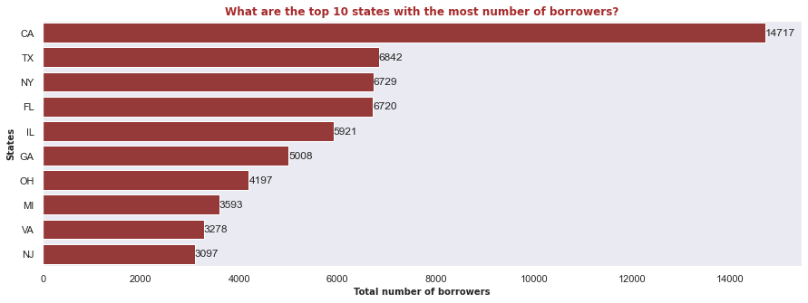

```python
sb.set(style='dark',)
plt.figure(figsize=(15,5))

ax=sb.barplot(x=most_borrower_totals, y=most_borrower_states, color = 'brown')
plt.xlabel('Total number of borrowers',size=10,fontname="DejaVu Sans", fontweight="bold")
plt.ylabel('States',size=10,fontname="DejaVu Sans", fontweight="bold")
plt.title('What are the top 10 states with the most number of borrowers?' , size=12, fontname="DejaVu Sans", color ="brown", fontweight="bold")


#lets now display the value lables using containers as shwoed in the class.
for i in ax.containers:
    ax.bar_label(i,)
```

# QN: What is the total number of borrowers who own homes?

**INSIGHT:** **We noted that the number of borrowers who owned homes was higher than that of those who didn't own one by a very small difference. 57,478 borrowers owned homes as compared to 56,459 who didn;t.**

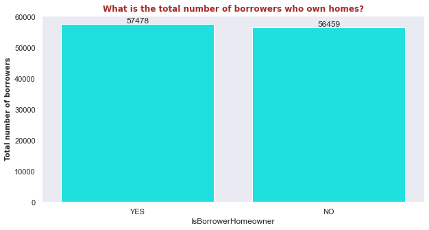

```python
sb.set(style='dark',)
fig = plt.figure(figsize=(10,5))

ax=sb.countplot(x='IsBorrowerHomeowner', data=loans_df_clean, color ="cyan")
plt.title('What is the total number of borrowers who own homes?',size=12, fontname="DejaVu Sans", color ="brown", fontweight="bold")
plt.ylabel('Total number of borrowers',size=10,fontname="DejaVu Sans", fontweight="bold")

#Lets display the totals on the top of the graphs.
ax.bar_label(ax.containers[0])
plt.show()
```

# QN What is the total number of borrowers by employment status?

**INSIGHT:** **It was observed that most borrowers were employed. A total of 100,899 borrowers were employed, 835 borrowers were not employed, 795 were retired, 5,347 had employment status listed as not available and 3,806 listed as others.**

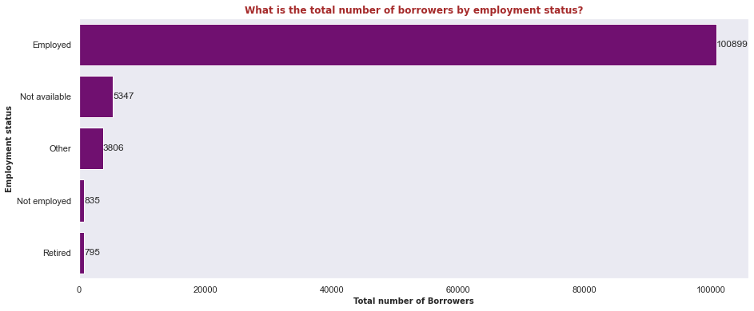

```python
sb.set(style='dark',)
fig = plt.figure(figsize=(15,6))
ax=sb.countplot(y='EmploymentStatus', data= loans_df_clean, color = 'purple')
plt.ylabel('Employment status', size=10,fontname="DejaVu Sans", fontweight="bold")
plt.xlabel('Total number of Borrowers',size=10,fontname="DejaVu Sans", fontweight="bold")
plt.title('What is the total number of borrowers by employment status?',size=12, fontname="DejaVu Sans", color ="brown", fontweight="bold")

for i in ax.containers:
    ax.bar_label(i,)
    plt.show()
```

# QN:What is the total number of borrowers by prosper score?

**INSIGHT:** **It was observed that borrowers with the lowest risk score (best) were few. Most borrowers had a high risk score ranging from 4 to 8.**

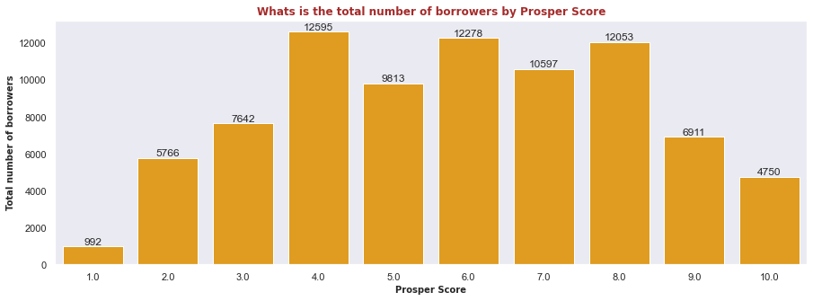

```python
sb.set(style='dark',)
fig = plt.figure(figsize=(15,5))
ax=sb.countplot(x='ProsperScore', data=prosper_clean,color='Orange')
plt.title('Whats is the total number of borrowers by Prosper Score',size=12, fontname="DejaVu Sans", color ="brown", fontweight="bold")
plt.xlabel('Prosper Score',size=10,fontname="DejaVu Sans", fontweight="bold")
plt.ylabel('Total number of borrowers',size=10,fontname="DejaVu Sans", fontweight="bold")
for i in ax.containers:
    ax.bar_label(i,)
    plt.show()
```

# QN: What are the total borrowers by loan status?

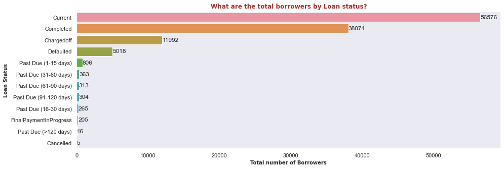

```python
sb.set(style='dark',)
fig = plt.figure(figsize=(15,5))
ax=sb.countplot(y='LoanStatus', data= loans_df_clean, order = loans_df_clean['LoanStatus'].value_counts().index)
plt.ylabel('Loan Status', size=10,fontname="DejaVu Sans", fontweight="bold")
plt.xlabel('Total number of Borrowers',size=10,fontname="DejaVu Sans", fontweight="bold")
plt.title('What are the total borrowers by Loan status?',size=12, fontname="DejaVu Sans", color ="brown", fontweight="bold")

for i in ax.containers:
    ax.bar_label(i,)
    plt.show()
```

# QN: What is the total distribution of Loans by Term [time taken]?

**INSIGHT:** **We noted that, most loans were for 36 with the least being for 12**

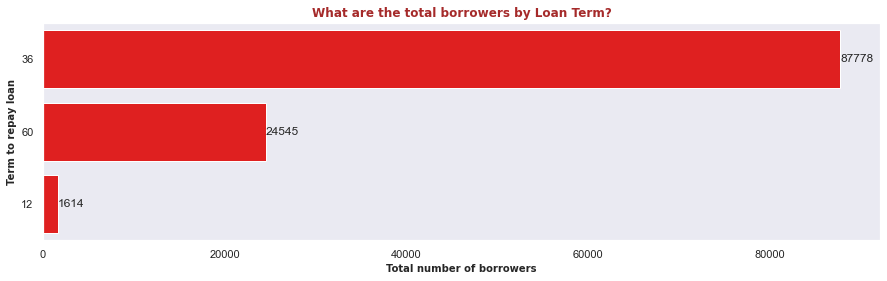

```python
sb.set(style='dark',)
fig = plt.figure(figsize=(15,4))
ax=sb.countplot(y='Term', data= loans_df_clean, color = "red", order = loans_df_clean['Term'].value_counts().index)
plt.ylabel('Term to repay loan', size=10,fontname="DejaVu Sans", fontweight="bold")
plt.xlabel('Total number of borrowers',size=10,fontname="DejaVu Sans", fontweight="bold")
plt.title('What are the total borrowers by Loan Term?',size=12, fontname="DejaVu Sans", color ="brown", fontweight="bold")

for i in ax.containers:
    ax.bar_label(i,)
    plt.show()
```

# QN: What is the correlation between prosper score and credit score?

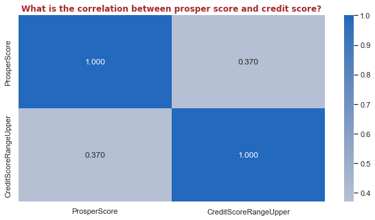

```python
num_var_1 = ['ProsperScore','CreditScoreRangeUpper']
plt.figure(figsize = [10, 5])
sb.heatmap(loans_df_clean[num_var_1].corr(), annot = True, fmt = '.3f', cmap = 'vlag_r', center = 0)
plt.title('What is the correlation between prosper score and credit score?',size=12, fontname="DejaVu Sans", color ="brown", fontweight="bold")
plt.show()
```

# QN: What is the correlation between prosper score and term?

**Correlation Inisght:** **There was no positive/strong relationship between Prosper Score and term. This was because even those who took small term loans could default.**

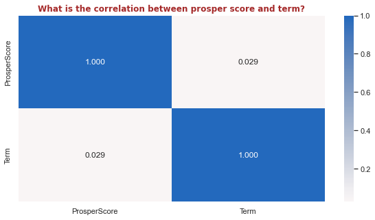

```python
num_var_2 = ['ProsperScore','Term']


plt.figure(figsize = [10, 5])
sb.heatmap(loans_df_clean[num_var_2].corr(), annot = True, fmt = '.3f',cmap = 'vlag_r', center = 0)
plt.title('What is the correlation between prosper score and term?',size=12, fontname="DejaVu Sans", color ="brown", fontweight="bold")
plt.show()
```

# QN: What is the correlation between BorrowerRate and Stated Monthly Income?

**Correlation Inisght:** **There was no positive/strong relationship between Borrower Rate and Stated Monthly Income. This was because loans can have a flat rate for all borrowers.**

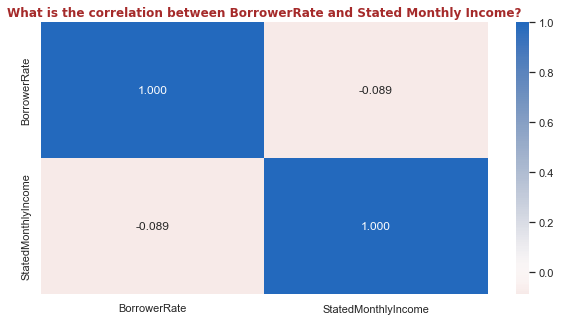

```python
num_vars_3 = ['BorrowerRate', 'StatedMonthlyIncome']

plt.figure(figsize = [10, 5])
sb.heatmap(loans_df_clean[num_vars_3].corr(), annot = True, fmt = '.3f',cmap = 'vlag_r', center = 0)
plt.title('What is the correlation between BorrowerRate and Stated Monthly Income?',size=12, fontname="DejaVu Sans", color ="brown", fontweight="bold")
plt.show()
```

# QN: What's the correlation between stated income and prosper scores ?

**Correlation Inisght:** **It was observed that there was a strong positive correlation between stated monthly income and Prosper score. The Higher the stated monthly income, the higher the prosper score. This was because borrowers who earned higher salaries were trusted to be more likely to payback.**

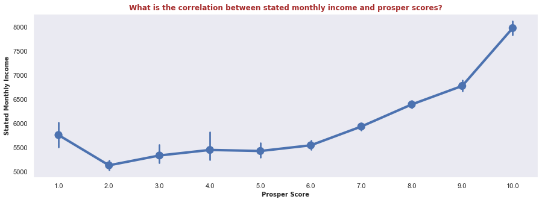

```python
fig = plt.figure(figsize=(15,5))
sb.pointplot(y='StatedMonthlyIncome', x='ProsperScore', data=prosper_clean,marker='o',scale = 1.5)
plt.title('What is the correlation between stated monthly income and prosper scores?',size=12, fontname="DejaVu Sans", color ="brown", fontweight="bold")
plt.xlabel('Prosper Score',size=10,fontname="DejaVu Sans", fontweight="bold")
plt.ylabel('Stated Monthly Income',size=10,fontname="DejaVu Sans", fontweight="bold")
plt.show()
```

# QN: What is the correlation between home ownership status and prosper score?

**Correlation Inisght:** **It was noted that most borrowers with the best prosper score [8 to 10] owned homes, while those with relatively high scores didn't own homes [2 to 3].**

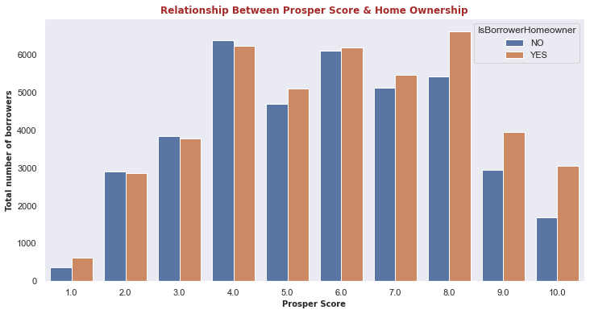

```python
fig = plt.figure(figsize=(12,6))
sb.countplot(hue='IsBorrowerHomeowner', x='ProsperScore', data=prosper_clean)
plt.title('Relationship Between Prosper Score & Home Ownership',size=12, fontname="DejaVu Sans", color ="brown", fontweight="bold")
plt.ylabel('Total number of borrowers',size=10,fontname="DejaVu Sans", fontweight="bold")
plt.xlabel('Prosper Score',size=10,fontname="DejaVu Sans", fontweight="bold")
plt.show()
```

# QN: What is the relationship between prosper score, borrower rate and estimated loss?

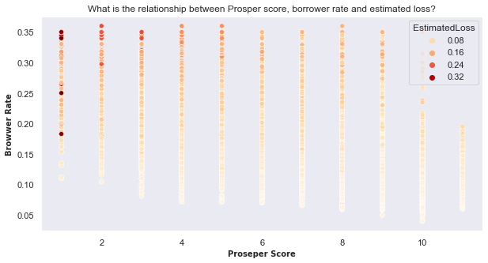

```python
fig = plt.figure(figsize=(10,5))
sb.scatterplot(x='ProsperScore', y='BorrowerRate',
                hue='EstimatedLoss',y_jitter=0.5, data=loans_df_clean, palette='OrRd')
plt.title('What is the relationship between Prosper score, borrower rate and estimated loss?')
plt.xlabel('Proseper Score',size=10,fontname="DejaVu Sans", fontweight="bold")
plt.ylabel('Browwer Rate',size=10,fontname="DejaVu Sans", fontweight="bold")
plt.show()
```

# QN: What is the relationship between prosper score, Loan amount and monthly loan payments ?

**Correlation Inisght:** **It was noted that a relationship exists between monthly loan payments and the loan original amount. A Higher Loan Amount taken by borrowers led to Higher monthly loan payments. It was also observed that the least/best prosper scores [8 to 10] got higher loans as compared to mostly those with higher prosper scores [2 to 6]**

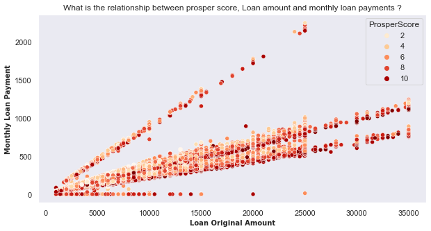

```python
fig = plt.figure(figsize=(10,5))
sb.scatterplot(x='LoanOriginalAmount', y='MonthlyLoanPayment',
                hue='ProsperScore',y_jitter=0.5, data=loans_df_clean, palette='OrRd')
plt.title('What is the relationship between prosper score, Loan amount and monthly loan payments ?')
plt.xlabel('Loan Original Amount',size=10,fontname="DejaVu Sans", fontweight="bold")
plt.ylabel('Monthly Loan Payment',size=10,fontname="DejaVu Sans", fontweight="bold")
plt.show()
```

# QN: What is the relationship between prosper score, home ownership and loan amount?

**Correlation Inisght:** **A relationship was observed among the three. Borrowers who were home owners and had the least prosper score took bigger loans. It was observed that most of the small loans ranging from 5000 to 15000 were mostly taken by borrowers who didn't own homes, it was also seen that borrower who owned and those who didn't, ended up getting lower loans as long as their propsper score was high. [2 to 6 and 5000 to 15000] range.**

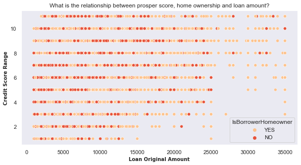

```python
fig = plt.figure(figsize=(10,5))
sb.scatterplot(x='LoanOriginalAmount', y='ProsperScore',
                hue='IsBorrowerHomeowner',y_jitter=0.5, data=loans_df_clean, palette='OrRd')
plt.title('What is the relationship between prosper score, home ownership and loan amount?')
plt.xlabel('Loan Original Amount',size=10,fontname="DejaVu Sans", fontweight="bold")
plt.ylabel('Credit Score Range',size=10,fontname="DejaVu Sans", fontweight="bold")
plt.show()
```

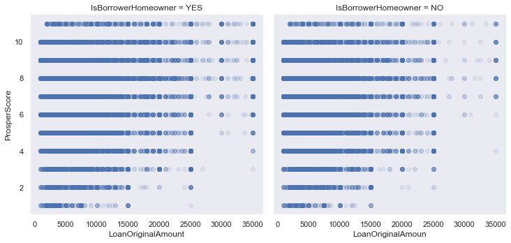

```python
fig = plt.figure(figsize=(20,5))

a=sb.FacetGrid(data = loans_df_clean, col = 'IsBorrowerHomeowner', col_wrap = 4, height = 5)
a.map(plt.scatter, 'LoanOriginalAmount', 'ProsperScore', alpha = 0.1,)
plt.xlabel('LoanOriginalAmoun')
plt.ylabel('ProsperScore')

plt.show()
```

### Talk about some of the relationships you observed in this part of the investigation. Were there features that strengthened each other in terms of looking at your feature(s) of interest?

> It can be observed that a relationship exists between monthly loan payments and the loan original amount. A Higher Loan Amount taken by borrowers leads to Higher monthly loan payments. It can also be observed that the least/best prosper scores [8 to 10] get higher loans as compared to mostly those with higher prosper scores [2 to 6]

### Were there any interesting or surprising interactions between features?

> Having no relationship between borrower rate and monthly salary was surprising